# PPG Paint Colors: Final Project Classification

Sai Vivek Chava

2023-12-12

```r
library(tidyverse, tidymodels)
library(caret)
df <- readr::read_csv("paint_project_train_data.csv", col_names = TRUE, show_col_types = F)
df %>% glimpse()
```

```
## Rows: 835
## Columns: 8
## $ R          <dbl> 172, 26, 172, 28, 170, 175, 90, 194, 171, 122, 0, 88, 144, …
## $ G          <dbl> 58, 88, 94, 87, 66, 89, 78, 106, 68, 151, 121, 140, 82, 163…
## $ B          <dbl> 62, 151, 58, 152, 58, 65, 136, 53, 107, 59, 88, 58, 132, 50…
## $ Lightness  <chr> "dark", "dark", "dark", "dark", "dark", "dark", "dark", "da…
## $ Saturation <chr> "bright", "bright", "bright", "bright", "bright", "bright",…
## $ Hue        <dbl> 4, 31, 8, 32, 5, 6, 34, 10, 1, 21, 24, 22, 36, 16, 26, 12, …
## $ response   <dbl> 12, 10, 16, 10, 11, 16, 10, 19, 14, 25, 14, 19, 14, 38, 15,…
## $ outcome    <dbl> 1, 1, 1, 0, 0, 0, 0, 0, 0, 0, 0, 0, 0, 0, 0, 0, 0, 0, 1, 1,…
```

```r
dfii <- df %>%
  mutate(y = ifelse(outcome == 1, 'event', 'non_event')) %>%
  mutate(y = factor(y, levels = c("event", "non_event"))) %>%
  select(R, G, B,
         Lightness, Saturation, Hue,y,
          outcome)

dfii %>% glimpse()
```

```
## Rows: 835
## Columns: 8
## $ R          <dbl> 172, 26, 172, 28, 170, 175, 90, 194, 171, 122, 0, 88, 144, …
## $ G          <dbl> 58, 88, 94, 87, 66, 89, 78, 106, 68, 151, 121, 140, 82, 163…
## $ B          <dbl> 62, 151, 58, 152, 58, 65, 136, 53, 107, 59, 88, 58, 132, 50…
## $ Lightness  <chr> "dark", "dark", "dark", "dark", "dark", "dark", "dark", "da…
## $ Saturation <chr> "bright", "bright", "bright", "bright", "bright", "bright",…
## $ Hue        <dbl> 4, 31, 8, 32, 5, 6, 34, 10, 1, 21, 24, 22, 36, 16, 26, 12, …
## $ y          <fct> event, event, event, non_event, non_event, non_event, non_e…
## $ outcome    <dbl> 1, 1, 1, 0, 0, 0, 0, 0, 0, 0, 0, 0, 0, 0, 0, 0, 0, 0, 1, 1,…
```

### Data Preprocessing

```r
set.seed(12321)

train_id <- createDataPartition(dfii$outcome, p = .8, list = FALSE)

df_train <- dfii[train_id,]

df_test <- dfii[-train_id,]
```

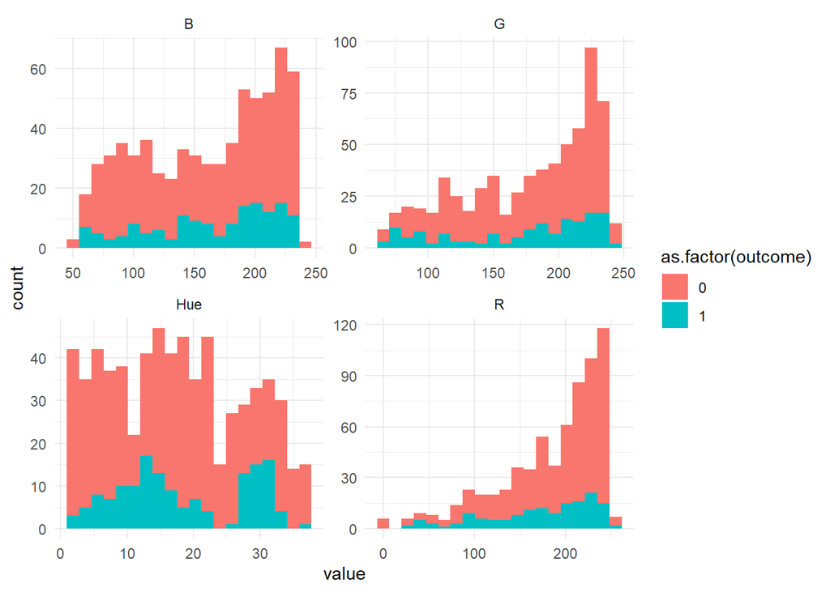

```r
df_train  %>%
  tibble::rowid_to_column() %>%
  pivot_longer(c(R, G, B, Hue)) %>% ggplot(mapping= aes(x = value, fill=as.factor(outcome))) +geom_histogram(bins = 20) + facet_wrap(~name, scales = 'free') +
  theme_minimal()
```

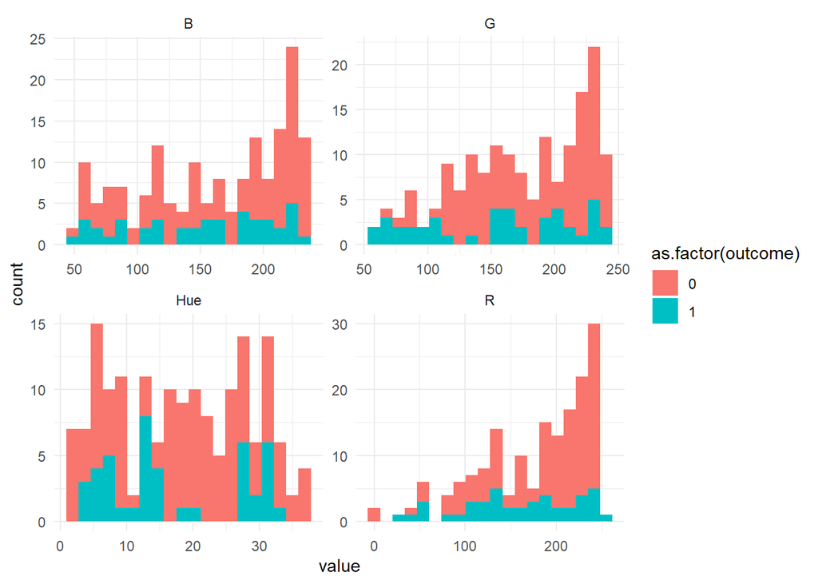

```r
df_test  %>%
  tibble::rowid_to_column() %>%
  pivot_longer(c(R, G, B, Hue)) %>% ggplot(mapping= aes(x = value, fill=as.factor(outcome))) +geom_histogram(bins = 20) + facet_wrap(~name, scales = 'free') +
  theme_minimal()
```

```r
cols_num <- c("R", "G", "B", "Hue")
var_mean <- as.vector(apply(df_train[,cols_num], 2, mean))
var_sd <- as.vector(apply(df_train[,cols_num], 2, sd))
df_train_stan  <- df_train[,cols_num] %>% scale(center = var_mean, scale = var_sd) %>%
  as.data.frame() %>% tibble::as_tibble() %>%
  bind_cols(df_train[,c('Lightness', 'Saturation', 'y', 'outcome')])

df_train_stan %>% glimpse()
```

```
## Rows: 668
## Columns: 8
## $ R          <dbl> -0.22845000, -2.78190834, -0.26391470, -0.17525295, -1.6825…
## $ G          <dbl> -1.6641451, -1.8044314, -2.2252904, -1.7643496, -1.9847996,…
## $ B          <dbl> -1.8961578, -0.1541894, -1.8961578, -1.7664368, -0.4506947,…
## $ Hue        <dbl> -0.94314293, 1.43578524, -1.24050895, -1.14138694, 1.634029…
## $ Lightness  <chr> "dark", "dark", "dark", "dark", "dark", "dark", "dark", "da…
## $ Saturation <chr> "bright", "bright", "bright", "bright", "bright", "bright",…
## $ y          <fct> event, non_event, non_event, non_event, non_event, non_even…
## $ outcome    <dbl> 1, 0, 0, 0, 0, 0, 0, 0, 0, 0, 0, 0, 1, 1, 1, 1, 1, 0, 0, 0,…
```

```r
df_test_stan <- df_test[,cols_num] %>% scale(center = var_mean, scale = var_sd) %>%
  as.data.frame() %>% tibble::as.tibble() %>%
  bind_cols(df_test[,c('Lightness', 'Saturation', 'y', 'outcome')])
df_test_stan %>% glimpse()
```

```
## Rows: 167
## Columns: 8
## $ R          <dbl> -0.22845000, -2.81737303, 0.16166169, -1.71796736, 0.161661…
## $ G          <dbl> -2.3856177, -1.7843905, -1.4236542, -0.7422635, -1.0027953,…
## $ B          <dbl> -1.8220315, -0.1727210, -1.9888157, -1.8961578, -1.9332210,…
## $ Hue        <dbl> -1.33963096, 1.33666323, -0.74489892, 0.44456517, -0.546654…
## $ Lightness  <chr> "dark", "dark", "dark", "dark", "dark", "dark", "dark", "da…
## $ Saturation <chr> "bright", "bright", "bright", "bright", "bright", "bright",…
## $ y          <fct> event, event, non_event, non_event, non_event, non_event, e…
## $ outcome    <dbl> 1, 1, 0, 0, 0, 0, 1, 1, 1, 0, 0, 0, 0, 1, 0, 0, 1, 0, 0, 1,…
```

# Classification

## GLM

```r
#Intercept only model no INPUTS
glm_intercept <- glm(outcome~1, data = df_train_stan)

#Categorical variables only linear additive
glm_category <- glm(outcome~Saturation + Lightness, family = 'binomial', data = df_train_stan)

#Continuous variables only linear additive
glm_continuous <- glm(outcome~R+G+B+Hue, family = 'binomial' , data = df_train_stan)

#All categorical and continuous variables linear additive
glm_all_linear <- glm(outcome~., family = 'binomial' , data = df_train_stan %>% select(-y))

#Interaction of the categorical inputs with all continuous inputs main effects
glm_cat_interaction <- glm(outcome~ Saturation*(R+G+B+Hue)+ Lightness *(R+G+B+Hue), family = 'binomial',
                           data = df_train_stan)

#Add categorical inputs to all main effect and all pairwise interactions of continuous
glm_cat_lin <- glm(outcome~Saturation+Lightness+(R+G+B+Hue)^2, family = 'binomial', data= df_train_stan)

# Interaction of the categorical inputs with all main effect and all pairwise interactions of continuous inputs
glm_cat_pairwise <- glm(outcome~Saturation*(R+G+B+Hue)^2 +Lightness*(R+G+B+Hue)^2, family = 'binomial',
                        data= df_train_stan)
# Interaction of Splines of Hue with 5 DoF with the linear and quadratic continuous variables and categorical
glm_basis_1 <- glm(outcome~(splines:: ns(Hue,5)) *(R+G+B+I(R^2)+I(G^2)+I(B^2)+Saturation+Lightness) ,
                   family = 'binomial', data = df_train_stan )
# interaction of splines of Hue with 5 DoF, linear additives of R,G,B, Lightness and Saturation
glm_basis_2 <- glm(outcome~(splines:: ns(Hue,5)) *(R+G+B+Lightness) * Saturation, family = 'binomial',
                 data = df_train_stan )
# Interaction between the Categorical and linear additives of Continuous variables
glm_basis_3 <- glm(outcome~(R+G+B+Hue+I(Hue^2))*Saturation*Lightness, family = 'binomial',
                   data = df_train_stan )
calculate_accuracy <- function(fitted_model, data) {

  predictions <- predict(fitted_model, newdata = data, type = "response")

  predicted_classes <- ifelse(predictions > 0.5, 1, 0)

  accuracy <- mean(predicted_classes == df_test$outcome)

  return(accuracy)
}
```

```r
summary_model <- tibble()
lm_list <- c('glm_intercept','glm_category','glm_continuous','glm_all_linear','glm_cat_interaction',
             'glm_cat_lin','glm_cat_pairwise','glm_basis_1','glm_basis_2','glm_basis_3')
 for (i in lm_list){
   Accuracy <- calculate_accuracy(get(i), df_test_stan %>% select(-y))
   result <-broom::glance(get(i)) %>% select(AIC, BIC)
   summary_model <- bind_rows(summary_model,tibble(Model=i, result, Accuracy))

 }

summary_model
```

```
## # A tibble: 10 × 4
##    Model                 AIC   BIC Accuracy
##    <chr>               <dbl> <dbl>    <dbl>
##  1 glm_intercept        726.  735.    0.743
##  2 glm_category         579.  638.    0.802
##  3 glm_continuous       695.  717.    0.749
##  4 glm_all_linear       574.  650.    0.802
##  5 glm_cat_interaction  569.  862.    0.778
##  6 glm_cat_lin          549.  653.    0.802
##  7 glm_cat_pairwise    5837. 6481.    0.820
##  8 glm_basis_1         4986. 5499.    0.826
##  9 glm_basis_2          840. 2732.    0.665
## 10 glm_basis_3         3327. 4652.    0.760
```

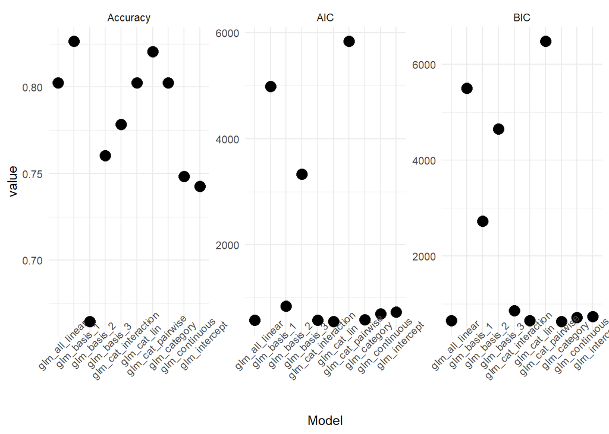

```r
 summary_model %>%
  pivot_longer(c(AIC, BIC, Accuracy)) %>%
  ggplot(mapping = aes(x = Model, y = value)) +
  geom_point(size = 4) +
  facet_wrap(~name, scales = 'free_y') +
  theme_minimal()+
  theme(axis.text.x = element_text(angle = 45))
```

```r
summary_model %>% arrange(AIC)
```

```
## # A tibble: 10 × 4
##    Model                 AIC   BIC Accuracy
##    <chr>               <dbl> <dbl>    <dbl>
##  1 glm_cat_lin          549.  653.    0.802
##  2 glm_cat_interaction  569.  862.    0.778
##  3 glm_all_linear       574.  650.    0.802
##  4 glm_category         579.  638.    0.802
##  5 glm_continuous       695.  717.    0.749
##  6 glm_intercept        726.  735.    0.743
##  7 glm_basis_2          840. 2732.    0.665
##  8 glm_basis_3         3327. 4652.    0.760
##  9 glm_basis_1         4986. 5499.    0.826
## 10 glm_cat_pairwise    5837. 6481.    0.820
```

**Which of the 10 models is the best? What performance metric did you use to make your selection**

From the plot above, we can see that AIC identifed model `glm_cat_lin` as the top performaer and BIC identified `glm_category` as the best model. The model `glm_all_linear` seems to have considerate low values of both BIC and AIC. Surprisingly, all the top 3 models has same accuracies.

Therefore the top 3 models are `glm_cat_lin`, `glm_all_linear` and `glm_category`.

**Visualize the coefficient summaries for your top 3 models.**

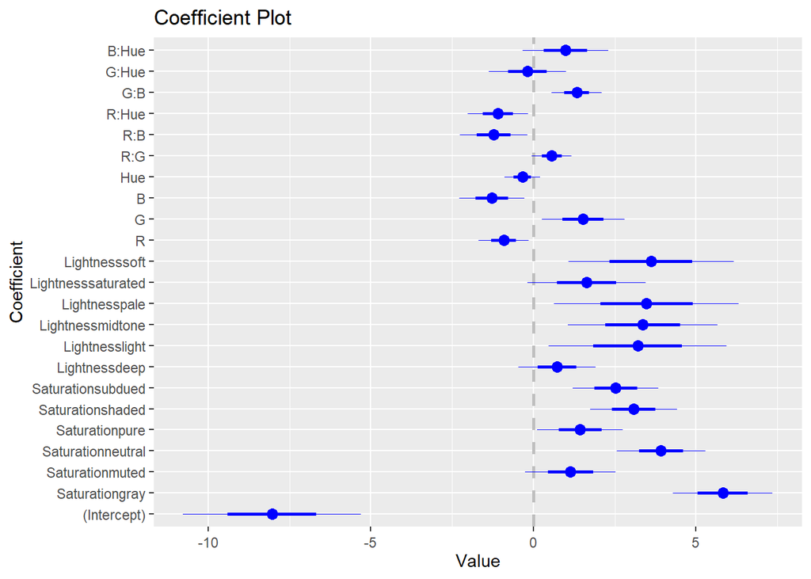

```r
coefplot::coefplot(glm_cat_lin)
```

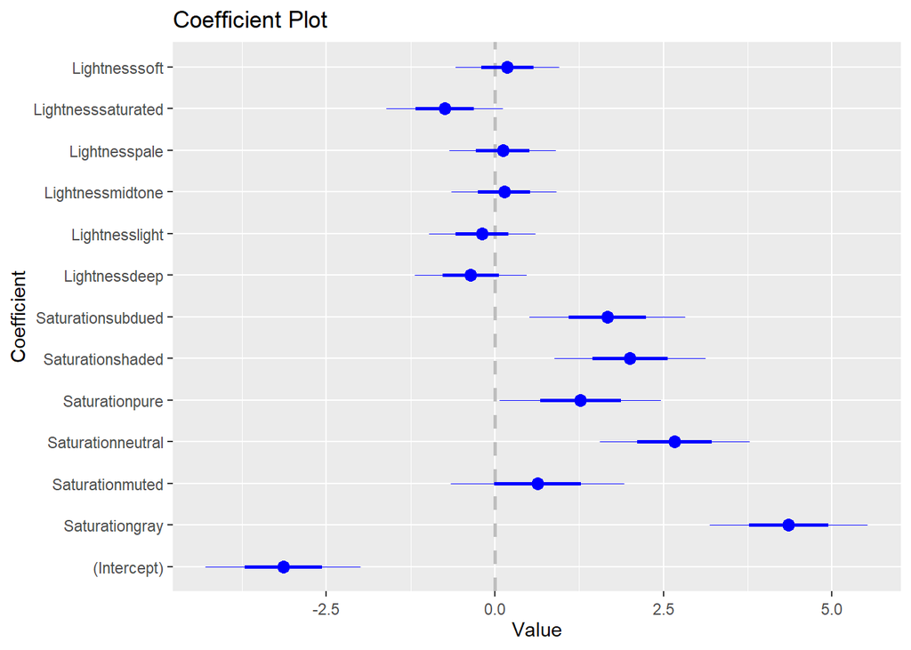

```r
coefplot::coefplot(glm_category)
```

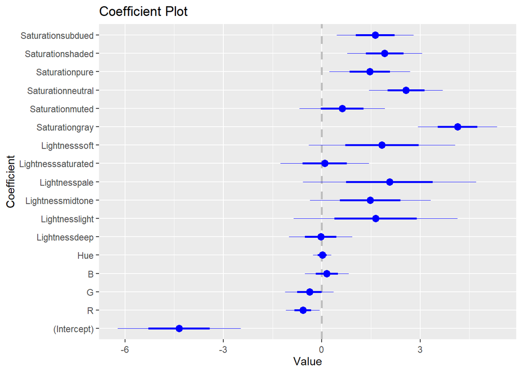

```r
coefplot::coefplot(glm_all_linear)
```

### Bayesian GLM

**State why you chose the second model.**

It’s the third best model with all the linear interactions between the inputs and has more statistical significant terms than the second best model.

```r
# model matrix of best model
Xmat_cat_lin <- model.matrix(formula(glm_cat_lin), data = df_test_stan)
# Model matrix of the third best model
Xmat_all_linear <- model.matrix(formula(glm_all_linear), data = df_test_stan)

info_cat_lin <- list(yobs = df$outcome,
                     design_matrix = Xmat_cat_lin,
                     mu_beta = 0,
                     tau_beta = 4.5)
info_all_linear <- list(yobs = df$outcome,
                     design_matrix = Xmat_all_linear,
                     mu_beta = 0,
                     tau_beta = 4.5)
```

```r
logistic_logpost <- function(unknowns, my_info)
{
  # extract the design matrix and assign to X
  X <- my_info$design_matrix

  # calculate the linear predictor
  eta <- X %*% as.matrix(unknowns)

  # calculate the event probability
  mu <- boot::inv.logit(eta)

  # evaluate the log-likelihood
  log_lik <- sum(dbinom( x = my_info$y, size =1 , prob = mu, log = TRUE))

  # evaluate the log-prior
  log_prior <- sum(dnorm(x = unknowns,mean = my_info$mu_beta, sd = my_info$tau_beta, log = TRUE))

  # sum together

  log_lik + log_prior

}
```

```r
my_laplace <- function(start_guess, logpost_func, ...)
{
  # code adapted from the `LearnBayes`` function `laplace()`
  fit <- optim(start_guess,
               logpost_func,
               gr = NULL,
               ...,
               method = "BFGS",
               hessian = TRUE,
               control = list(fnscale = -1, maxit = 5001))

  mode <- fit$par
  post_var_matrix <- -solve(fit$hessian)
  p <- length(mode)
  int <- p/2 * log(2 * pi) + 0.5 * log(det(post_var_matrix)) + logpost_func(mode, ...)
  # package all of the results into a list
  list(mode = mode,
       var_matrix = post_var_matrix,
       log_evidence = int,
       converge = ifelse(fit$convergence == 0,
                         "YES",
                         "NO"),
       iter_counts = as.numeric(fit$counts[1]))
}
```

```r
laplace_cat_lin <- my_laplace(rep(0,ncol(info_cat_lin$design_matrix)), logistic_logpost, info_cat_lin)

laplace_all_linear <- my_laplace(rep(0,ncol(info_all_linear$design_matrix)),
                                 logistic_logpost, info_all_linear)
```

```r
post_mode_cat_lin <- laplace_cat_lin$mode

post_sd_cat_lin <- sqrt(diag(laplace_cat_lin$var_matrix))

post_mode_all_lin <- laplace_all_linear$mode

post_sd_all_lin <- sqrt(diag(laplace_all_linear$var_matrix))
```

**Which performance metric did you use to make your selection?**

```r
exp(laplace_all_linear$log_evidence - laplace_cat_lin$log_evidence)
```

```
## [1] 25699876
```

This large value suggests that, based on the evidence provided by the data, the model represented by `laplace_all_linear` is vastly preferred over the model represented by laplace_cat_lin. The higher the value, the stronger the evidence in favor of the model in the numerator.

```r
viz_post_coefs <- function(post_means, post_sds, xnames)
{
  tibble::tibble(
    mu = post_means,
    sd = post_sds,
    x = xnames
  ) %>%
    mutate(x = factor(x, levels = xnames)) %>%
    ggplot(mapping = aes(x = x)) +
    geom_hline(yintercept = 0, color = 'grey', linetype = 'dashed') +
    geom_point(mapping = aes(y = mu)) +
    geom_linerange(mapping = aes(ymin = mu - 2 * sd,
                                 ymax = mu + 2 * sd,
                                 group = x)) +
    labs(x = 'feature', y = 'coefficient value') +
    coord_flip() +
    theme_minimal()
}
```

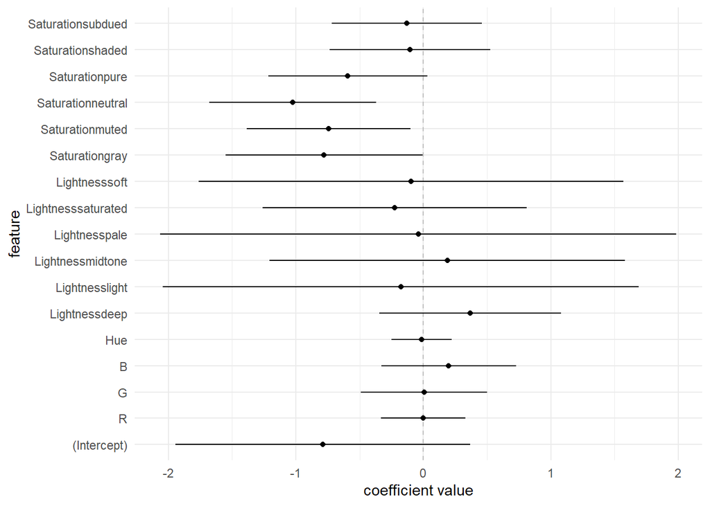

```r
viz_post_coefs(laplace_all_linear$mode[1:ncol(Xmat_all_linear)],
               sqrt(diag(laplace_all_linear$var_matrix))[1:ncol(Xmat_all_linear)],
               colnames(Xmat_all_linear))
```

##### Bayesian Model Intervals

```r
set.seed(1234)
viz_grid_glm <- expand.grid(
  G = seq(round(min(df_train_stan$G),4),round(max(df_train_stan$G),4),length.out=101),
  B = seq(round(min(df_train_stan$B),4),round(max(df_train_stan$B),4),length.out=6),
                        R = median(df_train_stan$R),
                        Hue = median(df_train_stan$Hue),
                        Saturation = unique(df_train_stan$Saturation),
                        Lightness = unique(df_train_stan$Lightness),
                        KEEP.OUT.ATTRS = FALSE,
                        stringsAsFactors = FALSE) %>%
  as.data.frame() %>% tibble::as_tibble()
viz_grid_glm %>% glimpse()
```

```
## Rows: 29,694
## Columns: 6
## $ G          <dbl> -2.285400, -2.249727, -2.214054, -2.178381, -2.142708, -2.1…
## $ B          <dbl> -2.1, -2.1, -2.1, -2.1, -2.1, -2.1, -2.1, -2.1, -2.1, -2.1,…
## $ R          <dbl> 0.3567175, 0.3567175, 0.3567175, 0.3567175, 0.3567175, 0.35…
## $ Hue        <dbl> -0.05104487, -0.05104487, -0.05104487, -0.05104487, -0.0510…
## $ Saturation <chr> "bright", "bright", "bright", "bright", "bright", "bright",…
## $ Lightness  <chr> "dark", "dark", "dark", "dark", "dark", "dark", "dark", "da…
```

```r
generate_glm_post_samples <- function(mvn_result, num_samples)
{
  # specify the number of unknown beta parameters
  length_beta <- length(mvn_result$mode)

  # generate the random samples
  beta_samples <-  MASS::mvrnorm(n = num_samples,
                mu = mvn_result$mode,
                Sigma = mvn_result$var_matrix)
  # change the data type and name
  beta_samples %>%
    as.data.frame() %>% tibble::as_tibble() %>%
    purrr::set_names(sprintf("beta_%02d", (1:length_beta) - 1))
}
```

```r
post_logistic_pred_samples <- function(Xnew, Bmat)
{
  # calculate the linear predictor at all prediction points and posterior samples
  eta_mat <-  Xnew%*%t(Bmat)

  # calculate the event probability
  mu_mat <-  boot::inv.logit(eta_mat)

  # book keeping
  list(eta_mat = eta_mat, mu_mat = mu_mat)
}
```

```r
summarize_logistic_pred_from_laplace <- function(mvn_result, Xtest, num_samples)
{
  # generate posterior samples of the beta parameters
  betas <- generate_glm_post_samples(mvn_result, num_samples)

  # data type conversion
  betas <- as.matrix(betas)

  # make posterior predictions on the test set
  pred_test <-  post_logistic_pred_samples(Xtest, betas)

  # calculate summary statistics on the posterior predicted probability
  # summarize over the posterior samples

  # posterior mean, should you summarize along rows (rowMeans) or
  # summarize down columns (colMeans) ???
  mu_avg <- rowMeans(pred_test$mu_mat)

  # posterior quantiles
  mu_q05 <- apply(pred_test$mu_mat, 1, stats::quantile, probs = 0.05)
  mu_q95 <- apply(pred_test$mu_mat, 1, stats::quantile, probs = 0.95)

  # book keeping
  tibble::tibble(
    mu_avg = mu_avg,
    mu_q05 = mu_q05,
    mu_q95 = mu_q95
  ) %>%
    tibble::rowid_to_column("pred_id")
}
```

```r
set.seed(3214)

bayes_glm_all_linear <- model.matrix(~ R + G + B + Hue + Lightness + Saturation, data = viz_grid_glm)

bayes_glm_cat_lin <- model.matrix(~ Saturation + Lightness + (R + G + B + Hue)^2, data = viz_grid_glm)
```

```r
set.seed(3214)

post_pred_all_lin <- summarize_logistic_pred_from_laplace(laplace_all_linear, bayes_glm_all_linear,3000)

post_pred_cat_lin <- summarize_logistic_pred_from_laplace(laplace_cat_lin, bayes_glm_cat_lin,3000)
```

```r
viz_bayes_logpost_preds <- function(post_pred_summary, input_df)
{
  post_pred_summary %>%
    left_join(input_df %>% tibble::rowid_to_column('pred_id'),
              by = 'pred_id') %>%
    ggplot(mapping = aes(x = G)) +
    geom_ribbon(mapping = aes(ymin = mu_q05, ymax = mu_q95), fill='yellow',
                alpha = 0.25) +
    geom_line(mapping = aes(y = mu_avg),
              size = 0.5) +
    facet_wrap( ~ B, labeller = 'label_both') +
    coord_cartesian(ylim = c(-.5,1))+
    labs(y = "event probability") +
    theme_minimal()
}
```

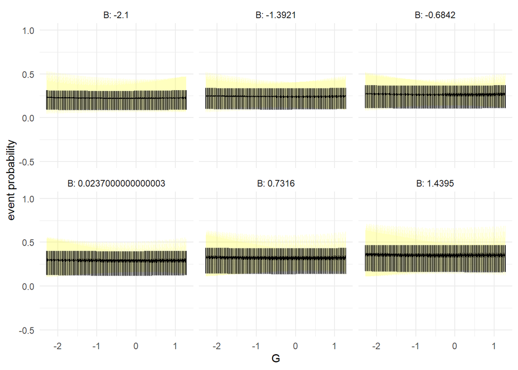

```r
viz_bayes_logpost_preds(post_pred_all_lin, viz_grid_glm)
```

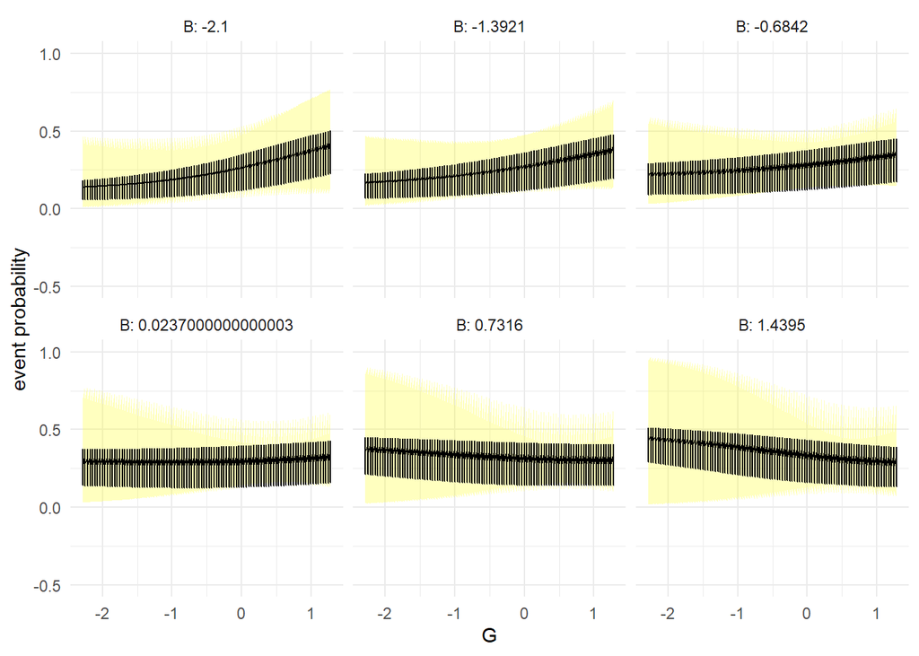

```r
viz_bayes_logpost_preds(post_pred_cat_lin, viz_grid_glm)
```

From the plot above, it can be seen that the prediction bounds as well with in the confidence intervals throughout the facets.

**You MUST state if the predictive trends are consistent between the 2 selected linear models.**

Upon observing the predictive trends of the both models, it can be said that both the models are consistent with their own prediction and confidence intervals but they are not same across the models.

# Train/Tune with resampling

```r
my_ctrl_1 <- trainControl(method = 'repeatedcv', number = 10, repeats = 3,
                         summaryFunction = twoClassSummary,
                         classProbs = TRUE,
                         savePredictions = TRUE)

my_metric <- 'ROC'
```

**All categorical and continuous inputs linear additive features**

```r
set.seed(1256)

mod_1_c <- train(y ~ R + G + B + Hue + Lightness + Saturation, method='glmnet', trControl = my_ctrl_1,
               preProcess=c('center', 'scale'), family='binomial', metric=my_metric,
               data = df_train)
mod_1_c %>% readr::write_rds("cls_mod_1.rds")
mod_1_c
```

```
## glmnet
##
## 668 samples
##   6 predictor
##   2 classes: 'event', 'non_event'
##
## Pre-processing: centered (16), scaled (16)
## Resampling: Cross-Validated (10 fold, repeated 3 times)
## Summary of sample sizes: 601, 602, 601, 601, 601, 601, ...
## Resampling results across tuning parameters:
##
##   alpha  lambda        ROC        Sens       Spec
##   0.10   0.0003503894  0.7863858  0.3476190  0.9602564
##   0.10   0.0035038941  0.7853053  0.3452381  0.9621795
##   0.10   0.0350389407  0.7733028  0.3360317  0.9673077
##   0.55   0.0003503894  0.7864316  0.3476190  0.9602564
##   0.55   0.0035038941  0.7852656  0.3407937  0.9634615
##   0.55   0.0350389407  0.7560745  0.3382540  0.9673077
##   1.00   0.0003503894  0.7862241  0.3498413  0.9602564
##   1.00   0.0035038941  0.7832082  0.3430159  0.9653846
##   1.00   0.0350389407  0.7165858  0.3382540  0.9673077
##
## ROC was used to select the optimal model using the largest value.
## The final values used for the model were alpha = 0.55 and lambda = 0.0003503894.
```

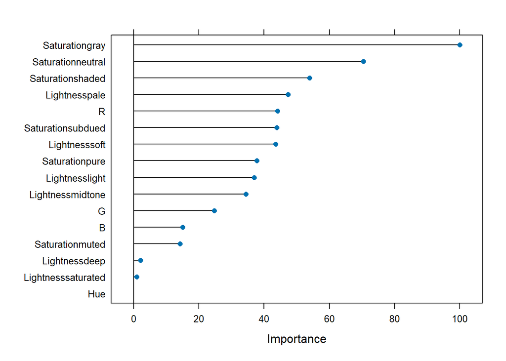

```r
plot(varImp(mod_1_c))
```

#### Model 2

**Add categorical inputs to all main effect and all pairwise interactions of continuous inputs**

```r
set.seed(1245)
mod_2_c <- train(y ~ Saturation + Lightness + (R + G + B + Hue)^2, method='glm', trControl = my_ctrl_1,
               preProcess= c('center', 'scale'), metric = my_metric,
               data= df_train)
mod_2_c %>% readr::write_rds("cls_mod_2.rds")
mod_2_c
```

```
## Generalized Linear Model
##
## 668 samples
##   6 predictor
##   2 classes: 'event', 'non_event'
##
## Pre-processing: centered (22), scaled (22)
## Resampling: Cross-Validated (10 fold, repeated 3 times)
## Summary of sample sizes: 601, 601, 601, 601, 601, 601, ...
## Resampling results:
##
##   ROC        Sens       Spec
##   0.8265934  0.3485714  0.9384615
```

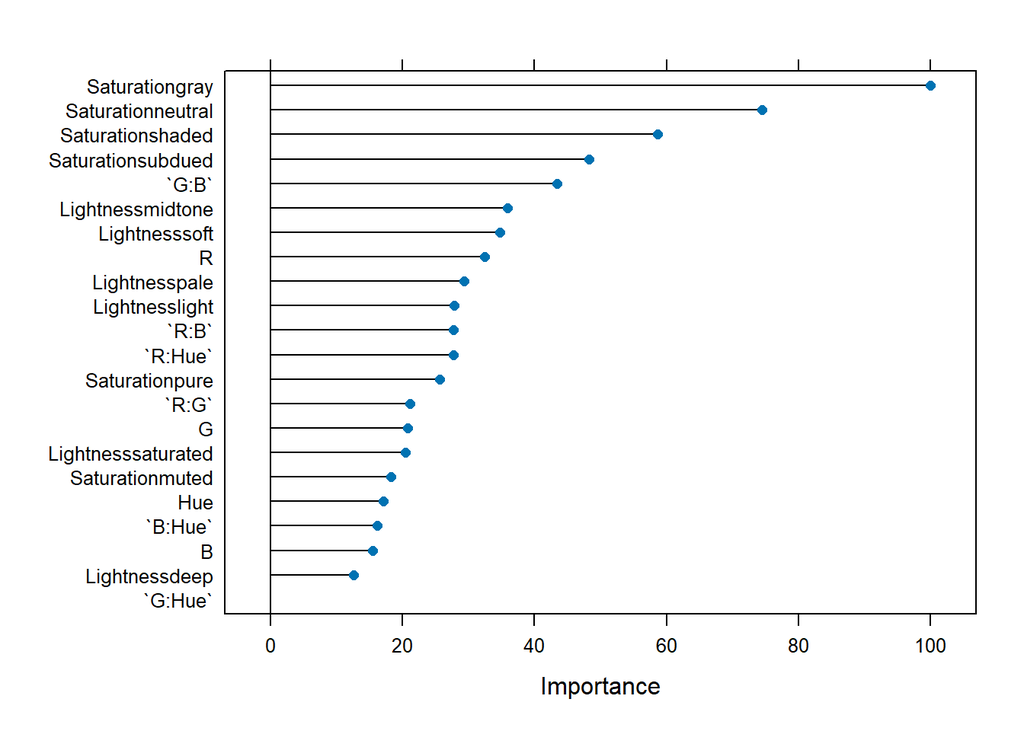

```r
plot(varImp(mod_2_c))
```

#### Model 3

```r
set.seed(12343)
mod_3_c <- train(y~ Saturation + Lightness, method= 'glm',
               trControl = my_ctrl_1, metric = my_metric,
               preProcess= c('center', 'scale'), data = df_train)
mod_3_c %>% readr::write_rds("cls_mod_3.rds")
mod_3_c
```

```
## Generalized Linear Model
##
## 668 samples
##   2 predictor
##   2 classes: 'event', 'non_event'
##
## Pre-processing: centered (12), scaled (12)
## Resampling: Cross-Validated (10 fold, repeated 3 times)
## Summary of sample sizes: 601, 601, 601, 601, 602, 602, ...
## Resampling results:
##
##   ROC        Sens       Spec
##   0.7805311  0.3374603  0.9647436
```

###Regularized regression with Elastic Net

#### Model 4

**Add categorical inputs to all main effect and all pairwise interactions of continuous inputs**

```r
set.seed(1234)
# training a default elastic net
enet_default <- train(y ~ Saturation + Lightness + (R + G + B + Hue)^2, method = 'glmnet',
                      metric = my_metric, trControl = my_ctrl_1,
                      preProcess= c('center', 'scale'), family='binomial',
                      data = df_train)
```

```r
lambda_grid <- exp(seq(log(min(enet_default$results$lambda)),
                          log(max(enet_default$results$lambda)), length.out = 25))
enet_grid <- expand.grid(alpha = seq(0.1,1, by=0.1),
                         lambda = lambda_grid)
```

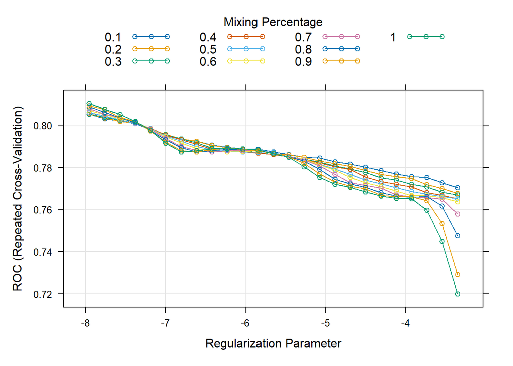

```r
set.seed(1234)

mod_4_c <- train(y ~ Saturation + Lightness + (R + G + B + Hue)^2, method = 'glmnet', metric = my_metric,
               trControl = my_ctrl_1, family = 'binomial',
               preProcess= c('center', 'scale'), tuneGrid = enet_grid, data = df_train)
mod_4_c %>% readr::write_rds("cls_mod_4.rds")
plot(mod_4_c, xTrans=log)
```

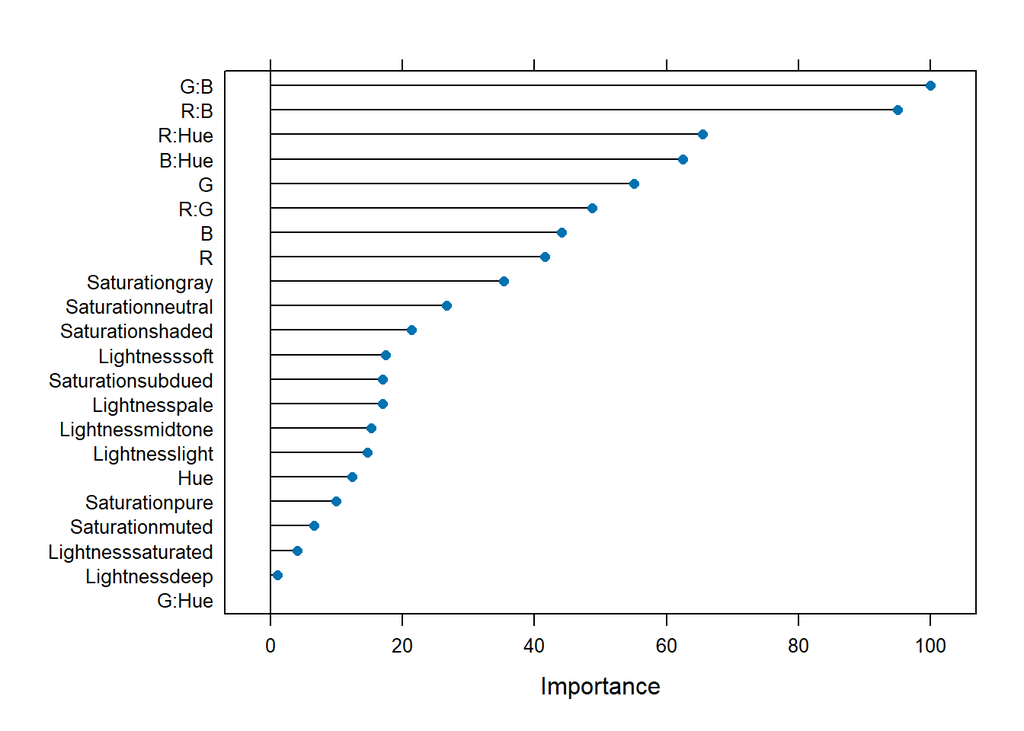

```r
plot(varImp(mod_4_c))
```

#### Model 5

**Add categorical inputs to all main effect and all pairwise interactions of continuous inputs**

```r
set.seed(12345)
# training a default elastic net
enet_1_default <- train(y ~ Saturation + Lightness + (R + G + B + Hue)^2, method = 'glmnet',
                        metric = my_metric, family='binomial',
                         trControl = my_ctrl_1, preProcess= c('center', 'scale'), data = df_train)

lambda_grid <- exp(seq(log(min(enet_1_default$results$lambda)),
                          log(max(enet_1_default$results$lambda)), length.out = 25))
enet_grid <- expand.grid(alpha = seq(0.1,1, by=0.1),
                         lambda = lambda_grid)
```

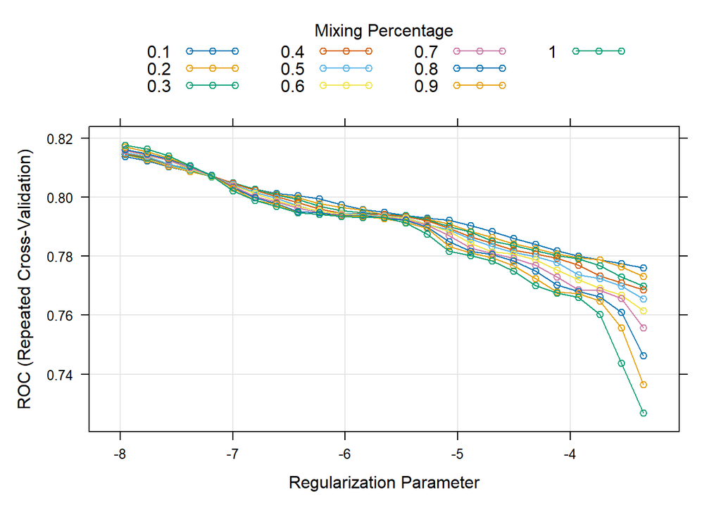

```r
set.seed(12335)
mod_5_c <- train(y ~ Saturation + Lightness + (R + G + B + Hue)^2, method = 'glmnet',
               metric = my_metric, trControl = my_ctrl_1, family = 'binomial',
               preProcess= c('center', 'scale'), tuneGrid = enet_grid, data = df_train)
mod_5_c %>% readr::write_rds("cls_mod_5.rds")
plot(mod_5_c, xTrans = log)
```

```r
mod_5_c$bestTune
```

```
##     alpha       lambda
## 226     1 0.0003503894
```

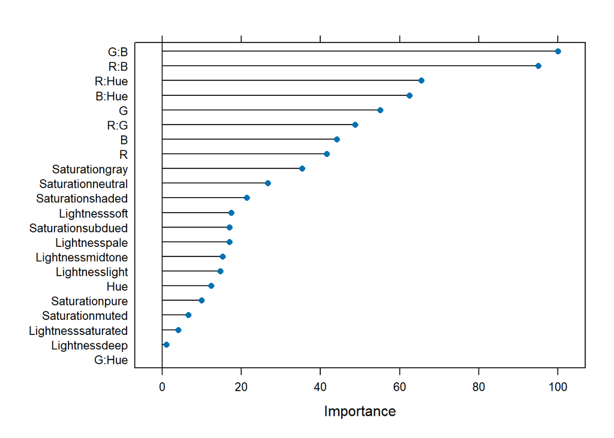

```r
plot(varImp(mod_5_c))
```

##### Model 6

**Neural Network**

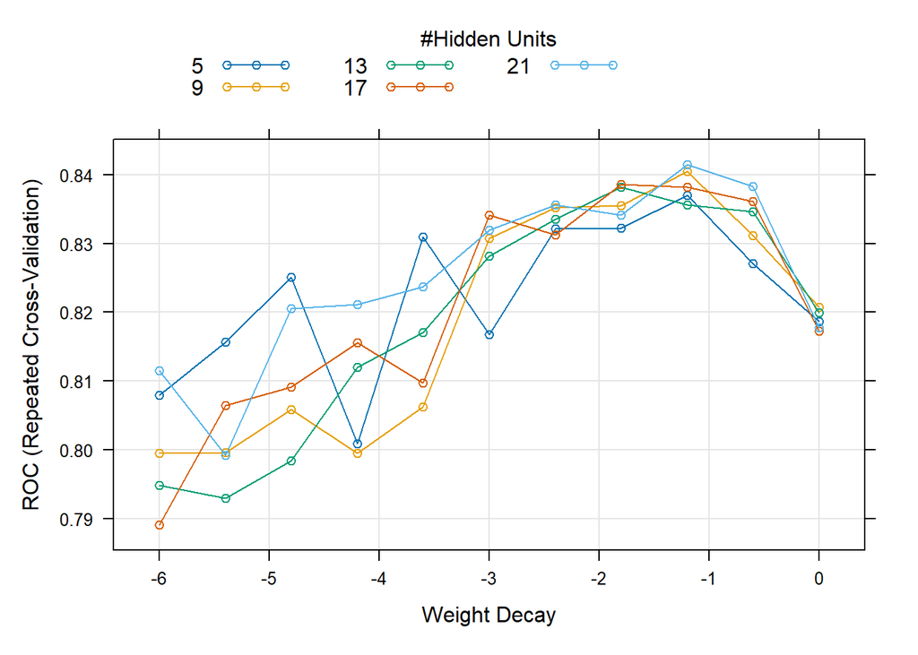

```r
set.seed(1234543)
nnet_grid <- expand.grid(size=c(5,9,13,17,21), decay=exp(seq(-6,0,length.out=11)))
mod_6_c <- train(y~R+G+B+Hue+Lightness+Saturation, method='nnet',
                 metric = my_metric, trControl = my_ctrl_1,
               trace=F, tuneGrid = nnet_grid, preProcess=c('center', 'scale'), family='binomial',
               data = df_train)
mod_6_c %>% readr::write_rds("cls_mod_6.rds")
plot(mod_6_c, xTrans = log)
```

```r
mod_6_c$bestTune
```

```
##    size     decay
## 53   21 0.3011942
```

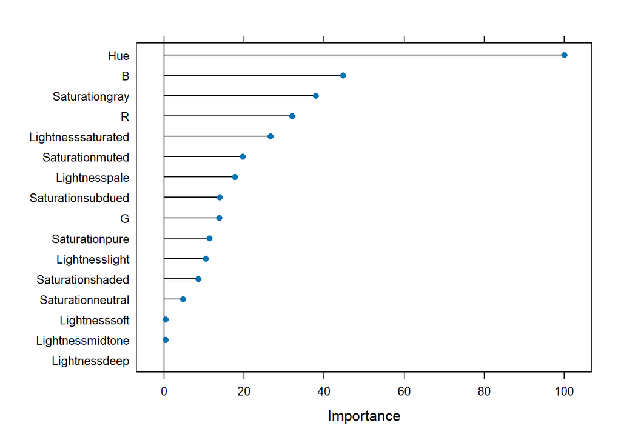

```r
plot(varImp(mod_6_c))
```

```r
set.seed(123342)
rf_grid <- expand.grid(mtry = c(1:7),
                          KEEP.OUT.ATTRS = FALSE,
                        stringsAsFactors = FALSE)

mod_7_c <- caret::train(y ~ R+G+B+Hue+Lightness+Saturation, method = 'rf',
                      data = df_train , family = 'binomial',
                      importance = TRUE,
                      metric = my_metric,
                      trControl = my_ctrl_1,
                      tuneGrid = rf_grid)
mod_7_c %>% readr::write_rds("cls_mod_7.rds")
mod_7_c
```

```
## Random Forest
##
## 668 samples
##   6 predictor
##   2 classes: 'event', 'non_event'
##
## No pre-processing
## Resampling: Cross-Validated (10 fold, repeated 3 times)
## Summary of sample sizes: 601, 601, 601, 601, 601, 601, ...
## Resampling results across tuning parameters:
##
##   mtry  ROC        Sens       Spec
##   1     0.8354930  0.0000000  1.0000000
##   2     0.8629289  0.2850794  0.9724359
##   3     0.8772802  0.4387302  0.9564103
##   4     0.8812469  0.4841270  0.9448718
##   5     0.8842643  0.5198413  0.9391026
##   6     0.8860485  0.5311111  0.9371795
##   7     0.8861172  0.5288889  0.9333333
##
## ROC was used to select the optimal model using the largest value.
## The final value used for the model was mtry = 7.
```

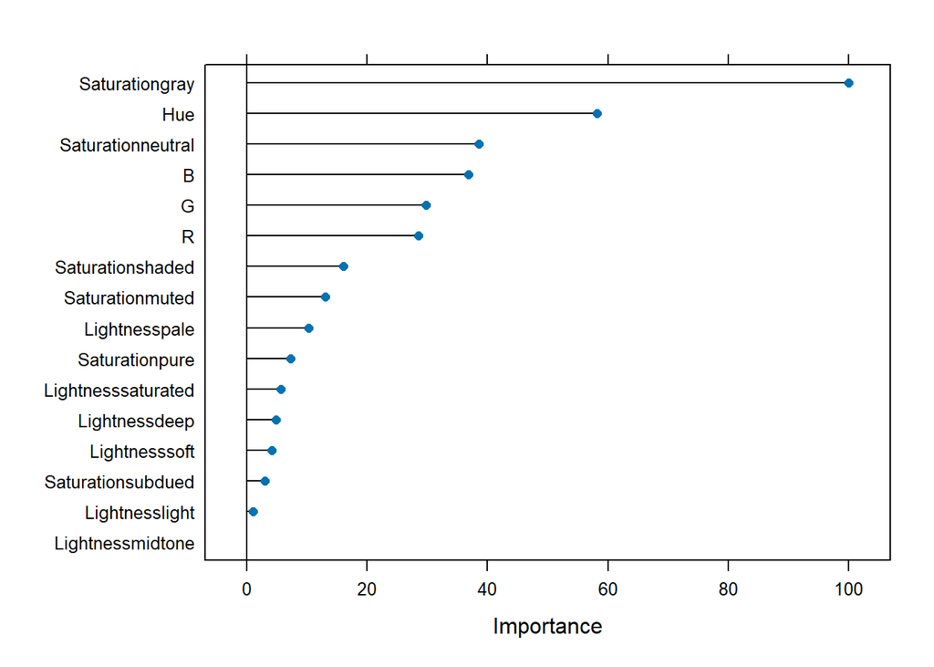

```r
plot(varImp(mod_7_c))
```

```r
mod_7_c$bestTune
```

```
##   mtry
## 7    7
```

#### Model 8

**Gradient Boosted Tree**

```r
set.seed(12233)
xgb_default <- train( y ~ R+G+B+Hue+Lightness+Saturation,
                      data = df_train, family='binomial',
                      method = 'xgbTree',
                      metric = my_metric,
                      trControl = my_ctrl_1,
                      verbosity = 0,
                      nthread = 1)
```

```r
set.seed(12234)
xgb_grid <- expand.grid(nrounds = c(25, 50, 100, 200, 400, 800),
                             max_depth = c(3, 6, 9),
                             eta =  c(0.0625*xgb_default$bestTune$eta,
                                      0.125*xgb_default$bestTune$eta,
                                      1.0*xgb_default$bestTune$eta),
                             gamma = xgb_default$bestTune$gamma,
                             colsample_bytree = xgb_default$bestTune$colsample_bytree,
                             min_child_weight = xgb_default$bestTune$min_child_weight,
                             subsample = xgb_default$bestTune$subsample)

mod_8_c <- train( y ~ R+G+B+Hue+Lightness+Saturation,
                   data = df_train, family = 'binomial',
                   method = 'xgbTree',
                   metric = my_metric,
                   tuneGrid = xgb_grid,
                   trControl = my_ctrl_1,
                   verbosity = 0,
                   nthread = 2)
mod_8_c %>% readr::write_rds("cls_mod_8.rds")
```

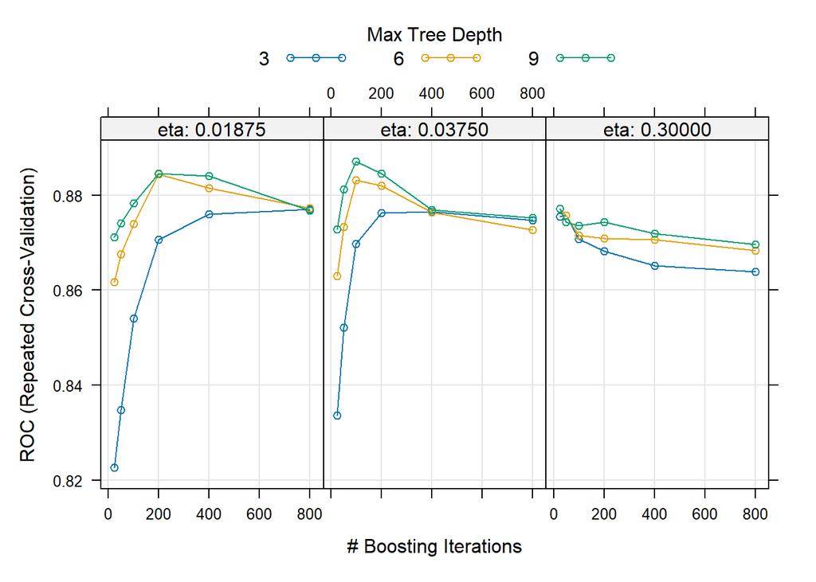

```r
plot(mod_8_c)
```

```r
mod_8_c$bestTune
```

```
##    nrounds max_depth    eta gamma colsample_bytree min_child_weight subsample
## 33     100         9 0.0375     0              0.8                1         1
```

##### Model 9

**KNN**

```r
set.seed(3333)

knn_grid <- expand.grid(k = 1:16)


mod_9_c <- train(y ~ R+G+B+Hue+Lightness+Saturation,
                    data = df_train,
                    method = "knn",
                    preProcess = c("center", "scale"),
                    metric = my_metric,
                    trControl = my_ctrl_1,
                tuneGrid = knn_grid)
mod_9_c %>% readr::write_rds("cls_mod_9.rds")
mod_9_c
```

```
## k-Nearest Neighbors
##
## 668 samples
##   6 predictor
##   2 classes: 'event', 'non_event'
##
## Pre-processing: centered (16), scaled (16)
## Resampling: Cross-Validated (10 fold, repeated 3 times)
## Summary of sample sizes: 601, 602, 601, 601, 601, 601, ...
## Resampling results across tuning parameters:
##
##   k   ROC        Sens       Spec
##    1  0.7117460  0.5568254  0.8666667
##    2  0.7545833  0.5238095  0.8455128
##    3  0.7723810  0.4992063  0.8891026
##    4  0.7827839  0.4466667  0.8974359
##    5  0.7784249  0.4312698  0.9198718
##    6  0.7689194  0.3925397  0.9198718
##    7  0.7614698  0.3744444  0.9262821
##    8  0.7577686  0.3785714  0.9294872
##    9  0.7525336  0.3782540  0.9467949
##   10  0.7491529  0.3376190  0.9435897
##   11  0.7474863  0.2992063  0.9564103
##   12  0.7458242  0.2706349  0.9602564
##   13  0.7471947  0.2298413  0.9685897
##   14  0.7469658  0.1890476  0.9705128
##   15  0.7461554  0.1644444  0.9737179
##   16  0.7459463  0.1306349  0.9762821
##
## ROC was used to select the optimal model using the largest value.
## The final value used for the model was k = 4.
```

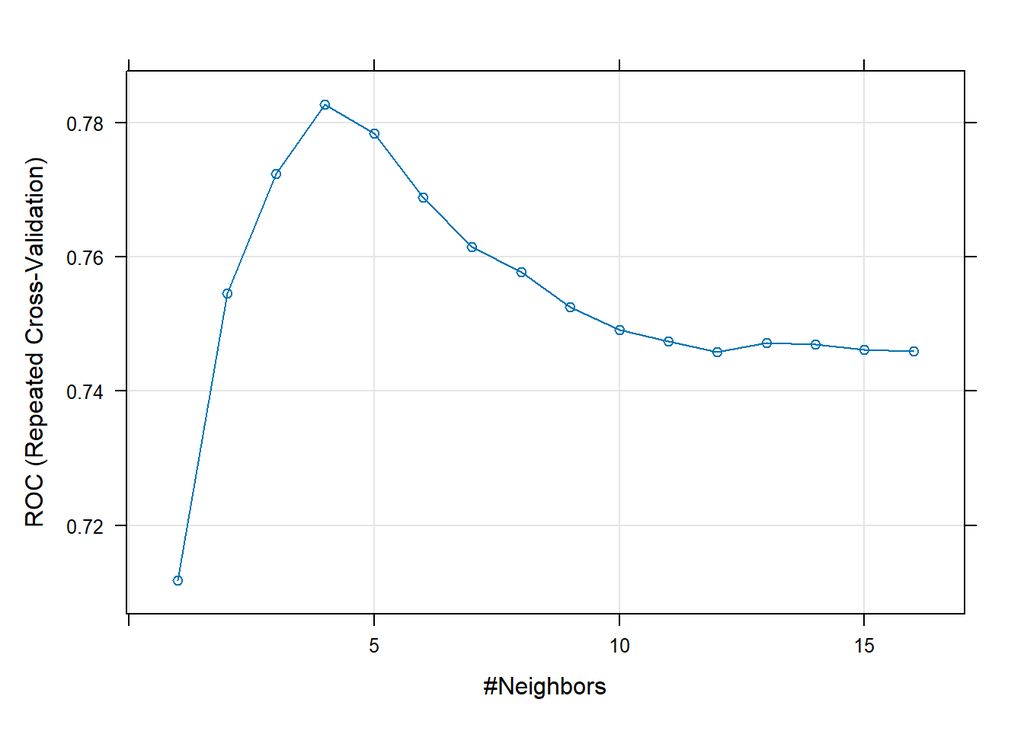

```r
plot(mod_9_c)
```